# Linear Models

## Poisson Error

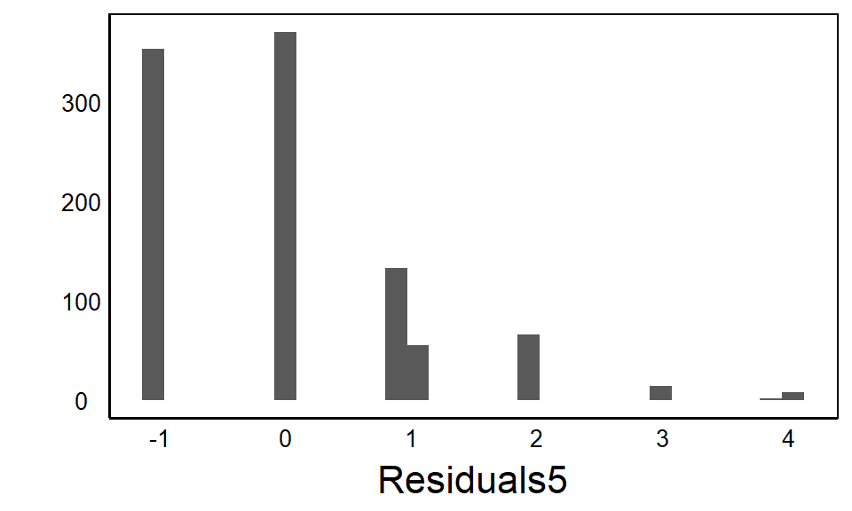

```r
# Make a new response variable
TestDat<-TestDat %>%
  mutate(Response5=B0+B1*PredCon+PredNomMean+rpois(N,lambda=1))

# Run the linear model
TestMod5<-lm(Response5 ~ PredCon + PredNom, data=TestDat)

# Calculate predictions and residuals of the linear model
TestDat$Predicted5<-predict(TestMod5)
TestDat$Residuals5<-residuals(TestMod5)

# Plot to look for problems
qplot(x=Residuals5, data=TestDat) # Histogram
```

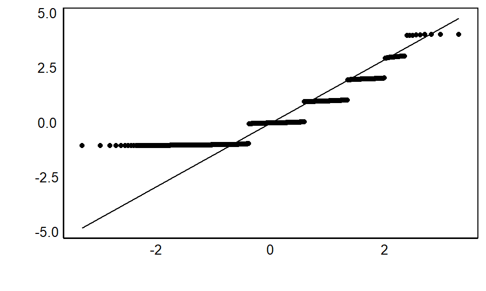

```r
qplot(sample=Residuals5, data=TestDat) + stat_qq() + stat_qq_line() # QQPlot
```

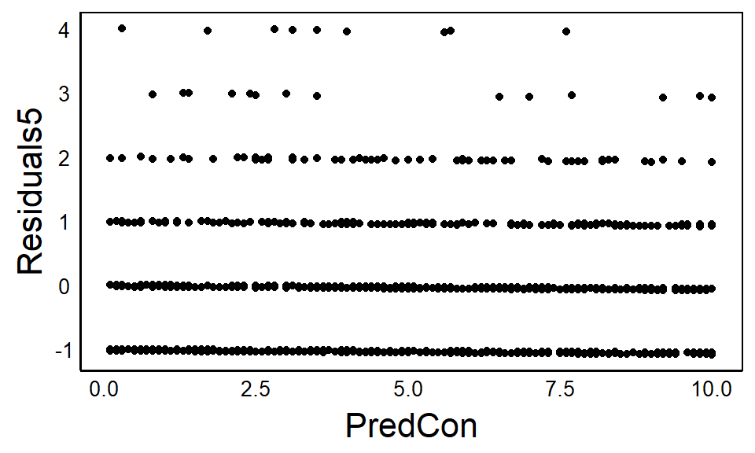

```r
qplot(x=PredCon, y=Residuals5, data=TestDat)
```

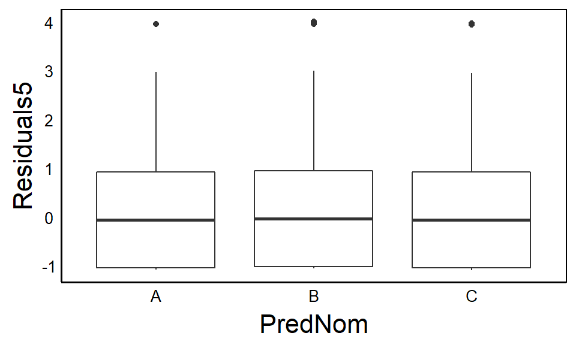

```r
qplot(x=PredNom, y=Residuals5, data=TestDat, geom="boxplot")
```

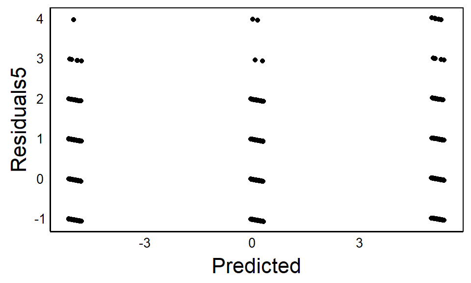

```r
qplot(x=Predicted, y=Residuals5, data=TestDat)
```

## Residuals matter most

Note that in our analysis above, we are analyzing the RESIDUALS. Our assumptions with linear models are about the residuals NOT the predictor or response variables.

Let’s look back at our original, well-behaved model as an example. Compare the histograms of the residuals with the response and predictors:

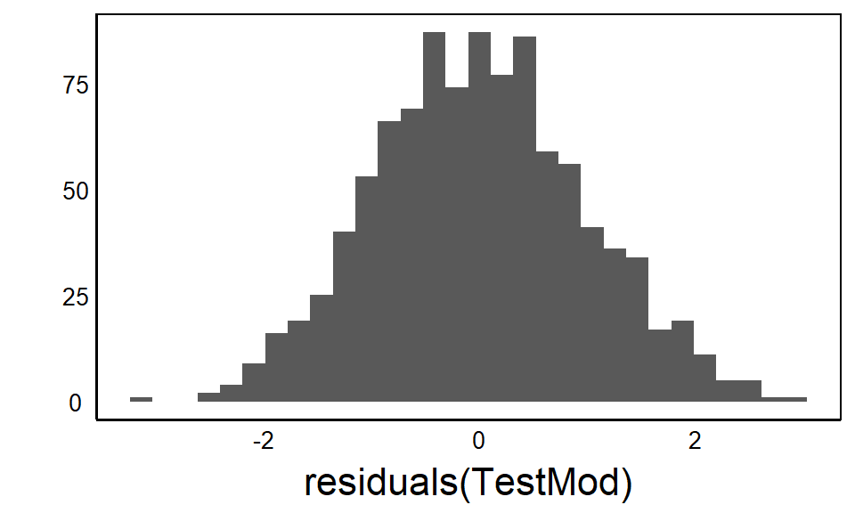

```r
qplot(residuals(TestMod))
```

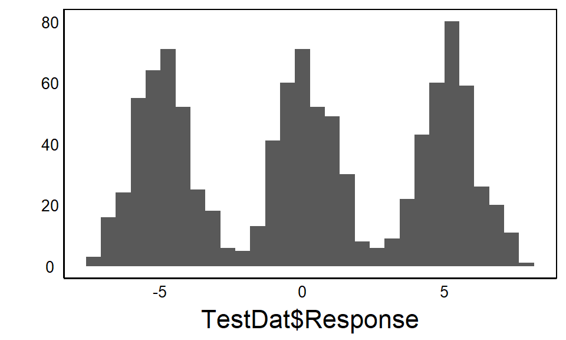

```r
qplot(TestDat$Response)
```

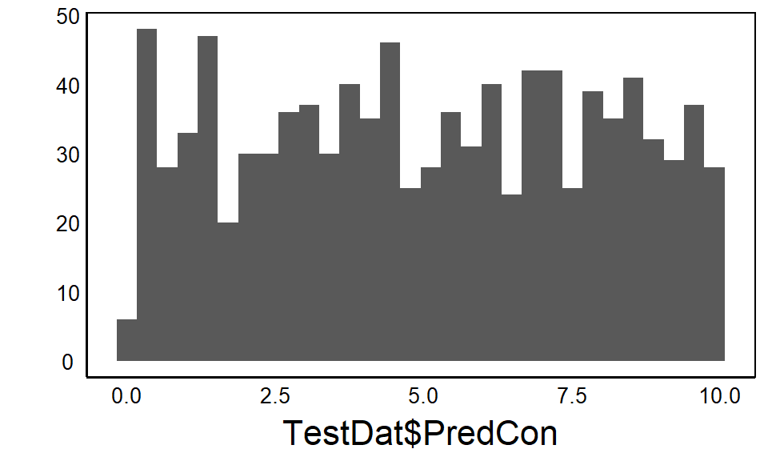

```r
qplot(TestDat$PredCon)
```

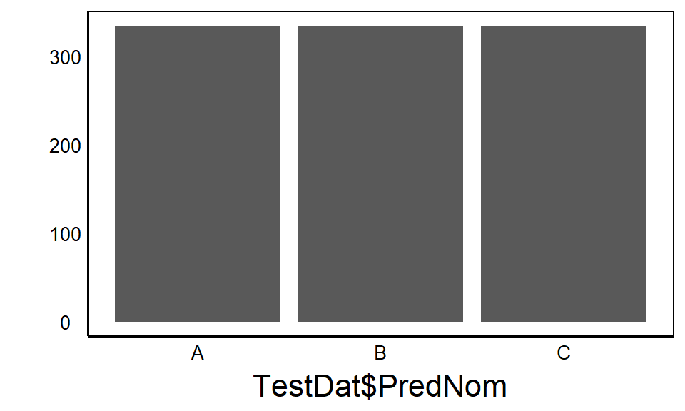

```r
qplot(TestDat$PredNom)
```

There is nothing wrong with the sample! It doesn’t matter that the predictors and response are not normally distributed, as long as the residuals are.